# 1-phase VSI

The circuit schematic and the corresponding gate signals for a single-phase inverter are shown below. The parameter values are $V_{dc}=400\,$V, $R=5\,\Omega$, $L=1\,$mH. Find the angle $\phi$ for which the RMS of the fundamental voltage $V_{BD}$ across the load is $100\,$V.

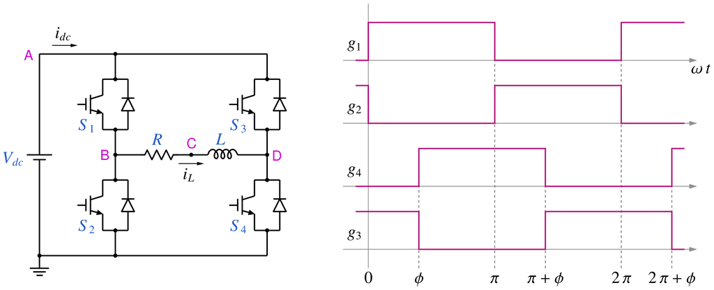

```python
from IPython.display import Image
Image(filename =r'VSI_1ph_15_fig_1.png', width=700)
```

```python
# run this cell to view the circuit file.
%pycat VSI_1ph_15_orig.in
```

We now replace the strings such as \$Vdc, \$L, with the values of our choice by running the python script given below. It takes an existing circuit file `VSI_1ph_15_orig.in` and produces a new circuit file `VSI_1ph_15.in`, after replacing \$Vdc, \$L, etc. with values of our choice.

```python
import gseim_calc as calc
s_Vdc = '400'
s_R = '5'
s_L = '1e-3'

phi = 110.0 # to be changed by user

s_f_hz = "50.0"
f_hz = float(s_f_hz)

T = 1/f_hz
t0_2 = T*phi/360

s_t0_2 = ("%11.4E"%(t0_2)).strip()

l = [
  ('$Vdc', s_Vdc),
  ('$R', s_R),
  ('$L', s_L),
  ('$f_hz', s_f_hz),
  ('$t0_2', s_t0_2)
]
calc.replace_strings_1("VSI_1ph_15_orig.in", "VSI_1ph_15.in", l)
print('VSI_1ph_15.in is ready for execution')
```

```
VSI_1ph_15.in is ready for execution
```

**Execute the following cell to run GSEIM on VSI_1ph_15.in.**

```python
import os
import dos_unix
# uncomment for windows:
#dos_unix.d2u("VSI_1ph_15.in")
os.system('run_gseim VSI_1ph_15.in')
```

```
Circuit: filename = VSI_1ph_15.in
main: calling solve_sss
solve_sss starting: sss_n_st: 1
solve_sss_ex: sss_iter_newton=0, rhs_sss_norm=7.8046e+01, sss_period_1_compute=4.0000e-02
solve_sss_ex: sss_iter_newton=1, rhs_sss_norm=0.0000e+00, sss_period_1_compute=4.0000e-02
solve_sss_ex: calling sss_solve_trns_ex for one more trns step
Transient simulation starts...
i=0
i=1000
GSEIM: Program completed.
```

```
0
```

The circuit file (`VSI_1ph_15.in`) is created in the same directory as that used for launching Jupyter notebook. The last step (i.e., running `GSEIM` on `VSI_1ph_15.in`) creates a data file called `VSI_1ph_15.dat`in the same directory. We can now use the python code below to compute/plot the various quantities of interest.

```
filename: VSI_1ph_15.dat
average source current:  2.9391E+01
rms source current:  4.7763E+01
rms load current:  4.8466E+01
rms load voltage:  2.4941E+02
peak load current:  7.9997E+01
power delivered to load:  1.1745E+04
```

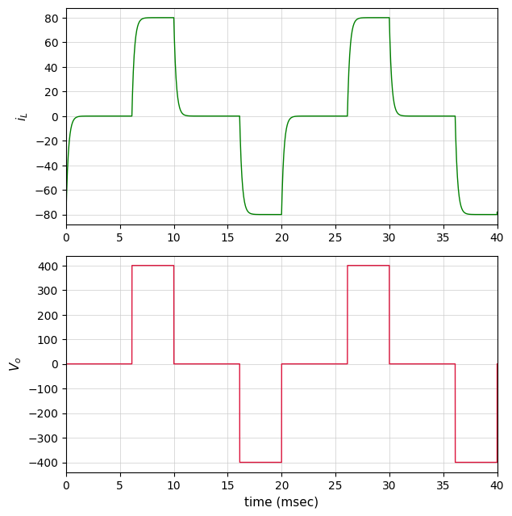

```python
import numpy as np
import matplotlib.pyplot as plt
import gseim_calc as calc
from setsize import set_size

slv = calc.slv("VSI_1ph_15.in")

i_slv = 0
i_out = 0
filename = slv.l_filename_all[i_slv][i_out]
print('filename:', filename)
u = np.loadtxt(filename)
t1 = u[:, 0]
t = 1e3*t1 # convert time to msec

v_out = slv.get_array_double(i_slv,i_out,"v_out",u)
IR    = slv.get_array_double(i_slv,i_out,"IR"   ,u)
ISrc  = slv.get_array_double(i_slv,i_out,"ISrc" ,u)
P_R   = slv.get_array_double(i_slv,i_out,"P_R"  ,u)
g1    = slv.get_array_double(i_slv,i_out,"g1"   ,u)
g2    = slv.get_array_double(i_slv,i_out,"g2"   ,u)
g3    = slv.get_array_double(i_slv,i_out,"g3"   ,u)
g4    = slv.get_array_double(i_slv,i_out,"g4"   ,u)

# since we have stored two cycles, we need to divide the last time point
# by 2 to get the period:

T = t[-1]/2

l_IR    = calc.avg_rms_3a(t, IR   , 0.0, 2.0*T, 1.0e-4*T)
l_P_R   = calc.avg_rms_3a(t, P_R  , 0.0, 2.0*T, 1.0e-4*T)
l_ISrc  = calc.avg_rms_3a(t, ISrc , 0.0, 2.0*T, 1.0e-4*T)
l_v_out = calc.avg_rms_3a(t, v_out, 0.0, 2.0*T, 1.0e-4*T)

l_IR_1 = calc.min_max_1(t, IR, 0.0, 2.0*T)

print('average source current:', "%11.4E"%l_ISrc[0])
print('rms source current:', "%11.4E"%l_ISrc[1])
print('rms load current:', "%11.4E"%l_IR[1])
print('rms load voltage:', "%11.4E"%l_v_out[1])
print('peak load current:', "%11.4E"%l_IR_1[1])
print('power delivered to load:', "%11.4E"%l_P_R[0])

color1='green'
color2='crimson'
color3='goldenrod'
color4='blue'

fig, ax = plt.subplots(2, sharex=False)
plt.subplots_adjust(wspace=0, hspace=0.0)

set_size(5, 5, ax[0])

for k in range(2):
    ax[k].grid(color='#CCCCCC', linestyle='solid', linewidth=0.5)
    ax[k].set_xlim(left=0.0, right=2.0*T)

ax[0].plot(t, IR   , color=color1, linewidth=1.0, label="$i_L$")
ax[1].plot(t, v_out, color=color2, linewidth=1.0, label="$V_o$")
ax[1].set_xlabel('time (msec)', fontsize=11)

ax[0].set_ylabel(r'$i_L$', fontsize=11)
ax[1].set_ylabel(r'$V_o$', fontsize=11)

plt.tight_layout()
plt.show()
```

```
filename: VSI_1ph_15.dat
```

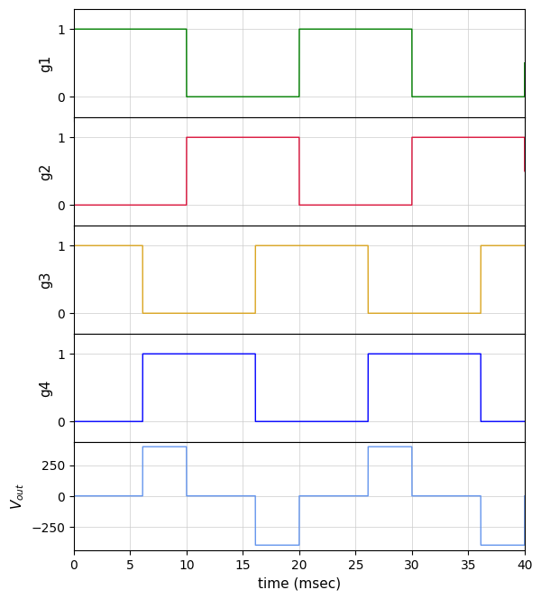

```python
import numpy as np
import matplotlib.pyplot as plt
import gseim_calc as calc
from setsize import set_size

slv = calc.slv("VSI_1ph_15.in")

i_slv = 0
i_out = 0
filename = slv.l_filename_all[i_slv][i_out]
print('filename:', filename)
u = np.loadtxt(filename)
t1 = u[:, 0]
t = 1e3*t1 # convert time to msec

v_out = slv.get_array_double(i_slv,i_out,"v_out",u)
IR    = slv.get_array_double(i_slv,i_out,"IR"   ,u)
ISrc  = slv.get_array_double(i_slv,i_out,"ISrc" ,u)
P_R   = slv.get_array_double(i_slv,i_out,"P_R"  ,u)
g1    = slv.get_array_double(i_slv,i_out,"g1"   ,u)
g2    = slv.get_array_double(i_slv,i_out,"g2"   ,u)
g3    = slv.get_array_double(i_slv,i_out,"g3"   ,u)
g4    = slv.get_array_double(i_slv,i_out,"g4"   ,u)

# since we have stored two cycles, we need to divide the last time point
# by 2 to get the period:

T = t[-1]/2

color1='green'
color2='crimson'
color3='goldenrod'
color4='blue'
color5='cornflowerblue'

fig, ax = plt.subplots(5, sharex=True)
plt.subplots_adjust(wspace=0, hspace=0.0)

set_size(5, 6, ax[0])

for i in range(4):
    ax[i].grid(color='#CCCCCC', linestyle='solid', linewidth=0.5)
    ax[i].set_xlim(left=0.0, right=2.0*T)
    ax[i].set_ylim(bottom=-0.3, top=1.3)
    ax[i].set_yticks([0.0, 1.0])

ax[0].plot(t, g1, color=color1, linewidth=1.0)
ax[0].set_ylabel('g1', fontsize=11)

ax[1].plot(t, g2, color=color2, linewidth=1.0)
ax[1].set_ylabel('g2', fontsize=11)

ax[2].plot(t, g3, color=color3, linewidth=1.0)
ax[2].set_ylabel('g3', fontsize=11)

ax[3].plot(t, g4, color=color4, linewidth=1.0)
ax[3].set_ylabel('g4', fontsize=11)

ax[4].grid(color='#CCCCCC', linestyle='solid', linewidth=0.5)
ax[4].set_xlim(left=0.0, right=2.0*T)
ax[4].plot(t, v_out, color=color5, linewidth=1.0)
ax[4].set_ylabel("$V_{out}$", fontsize=11)

ax[4].set_xlabel('time (msec)', fontsize=11)

plt.show()
```

```
filename: VSI_1ph_15.dat
fourier coefficients (load current):
    0  5.1005E-04
    1  5.8283E+01
    2  1.0099E-03
    3  3.2119E+01
    4  9.8091E-04
    5  1.6798E+00
    6  9.3728E-04
    7  1.1884E+01
    8  8.8421E-04
    9  6.8074E+00
   10  8.2655E-04
   11  3.1225E+00
   12  7.6803E-04
```

[output cut: 38 more lines]

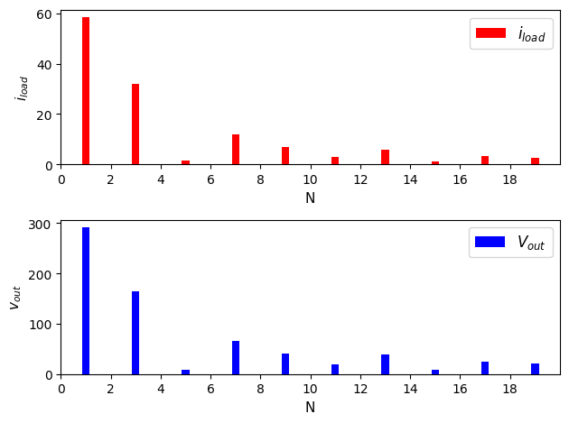

```python
import numpy as np
import matplotlib.pyplot as plt
import gseim_calc as calc
from setsize import set_size

slv = calc.slv("VSI_1ph_15.in")

i_slv = 0
i_out = 0
filename = slv.l_filename_all[i_slv][i_out]
print('filename:', filename)
u = np.loadtxt(filename)
t = u[:, 0]

v_out = slv.get_array_double(i_slv,i_out,"v_out",u)
IR    = slv.get_array_double(i_slv,i_out,"IR"   ,u)
ISrc  = slv.get_array_double(i_slv,i_out,"ISrc" ,u)
P_R   = slv.get_array_double(i_slv,i_out,"P_R"  ,u)
g1    = slv.get_array_double(i_slv,i_out,"g1"   ,u)
g2    = slv.get_array_double(i_slv,i_out,"g2"   ,u)
g3    = slv.get_array_double(i_slv,i_out,"g3"   ,u)
g4    = slv.get_array_double(i_slv,i_out,"g4"   ,u)

T = t[-1]/2

# compute Fourier coeffs:

t_start = 0.0
t_end = T

n_fourier_IR = 20
coeff_IR, thd_IR = calc.fourier_coeff_1C(t, IR,
    t_start, t_end, 1.0e-4*T, n_fourier_IR)
print('fourier coefficients (load current):')
for i, c in enumerate(coeff_IR):
    print("  %3d %11.4E"% (i, c))
print("THD (load current): ", "%5.2f"%(thd_IR*100.0), "%")
print("load current fundamental: RMS value: ", "%11.4E"%(coeff_IR[1]/np.sqrt(2.0)))
print("load current 3rd harmonic: RMS value: ", "%11.4E"%(coeff_IR[3]/np.sqrt(2.0)))
print("load current 5th harmonic: RMS value: ", "%11.4E"%(coeff_IR[5]/np.sqrt(2.0)))

n_fourier_v_out = 20
coeff_v_out, thd_v_out = calc.fourier_coeff_1C(t, v_out,
    t_start, t_end, 1.0e-4*T, n_fourier_v_out)
print('fourier coefficients (load voltage):')
for i, c in enumerate(coeff_v_out):
    print("  %3d %11.4E"% (i, c))
print("THD (load voltage): ", "%5.2f"%(thd_v_out*100.0), "%")
print("load voltage fundamental: RMS value: ", "%11.4E"%(coeff_v_out[1]/np.sqrt(2.0)))
print("load voltage 3rd harmonic: RMS value: ", "%11.4E"%(coeff_v_out[3]/np.sqrt(2.0)))
print("load voltage 5th harmonic: RMS value: ", "%11.4E"%(coeff_v_out[5]/np.sqrt(2.0)))

x_IR = np.linspace(0, n_fourier_IR, n_fourier_IR+1)
x_v_out = np.linspace(0, n_fourier_v_out, n_fourier_v_out+1)

y_IR = np.array(coeff_IR)
y_v_out = np.array(coeff_v_out)

fig, ax = plt.subplots(2, sharex=False)

bars1 = ax[0].bar(x_IR, y_IR, width=0.3, color='red', label="$i_{load}$")
bars2 = ax[1].bar(x_v_out, y_v_out, width=0.3, color='blue', label="$V_{out}$")

ax[0].set_xlabel('N', fontsize=11)
ax[0].set_ylabel('$i_{load}$', fontsize=11)
ax[0].set_xlim(left=0, right=n_fourier_IR)
ax[0].xaxis.set_ticks(np.arange(0, n_fourier_IR, 2))
ax[0].legend(loc = 'upper right',frameon = True, fontsize = 10, title = None,
   markerfirst = True, markerscale = 1.0, labelspacing = 0.5, columnspacing = 2.0,
   prop = {'size' : 12},)

ax[1].set_xlabel('N', fontsize=11)
ax[1].set_ylabel('$v_{out}$', fontsize=11)
ax[1].set_xlim(left=0, right=n_fourier_v_out)
ax[1].xaxis.set_ticks(np.arange(0, n_fourier_v_out, 2))
ax[1].legend(loc = 'upper right',frameon = True, fontsize = 10, title = None,
   markerfirst = True, markerscale = 1.0, labelspacing = 0.5, columnspacing = 2.0,
   prop = {'size' : 12},)

plt.tight_layout()
plt.show()
```

This notebook was contributed by **Prof. Nakul Narayanan K**, Govt. Engineering College, Thrissur. He may be contacted at nakul@gectcr.ac.in.